# Assessing Normality

Introducing a New Chart

Author

Nathan Lunceford

# Assessing Normality

When we use either the normal distribution or the t-distribution, we must confirm that the distribution of sample means is normally distributed. This is true when:

1. The population is normally distributed
2. $n > 30$ because of the Central Limit Theorem

But how do you know if a population is normally distributed? In the real world, there is no teacher to tell you when to assume a population is normal.

If our sample size is large enough, we don’t have to worry. We can trust the Central Limit Theorem.

If our sample size is < 30, we can assess the normality of our sample to decide if we can still trust output of our hypothesis tests and confidence intervals.

Previously, we’ve used histograms to help understand the distribution of a sample. However, when sample sizes are small, even samples from a standard normal distribution can look skewed.

All of the examples below are examples of random samples from actual normal distributions:

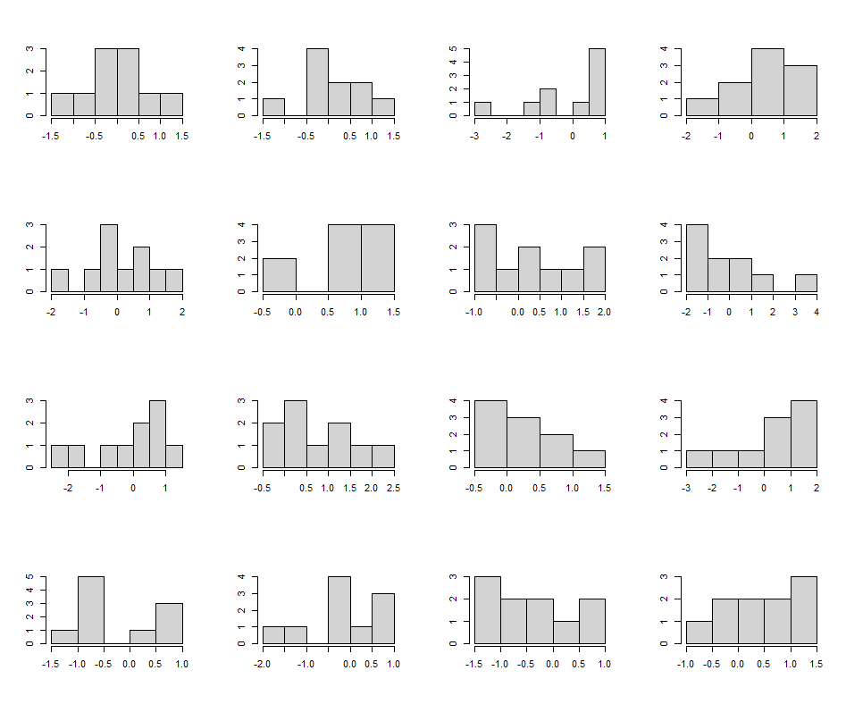

### A New Way to Assess Normality

Statisticians use something called a `QQPlot` which works better at assessing normality. QQPlots plot the sorted data of each point in a dataset with the theoretical percentile from a normal distribution. If the data and theoretical percentiles line up, then we can be reasonably sure the population is normally distributed.

These are easier to use than to explain. We use the `car` library and the function `qqPlot()` to create a chart.

**Key Point**: If most of the data points line up in the shaded region, we can consider the population as normally distributed.

Below are examples of QQPlots for a normal distribution and a right skewed distribution.

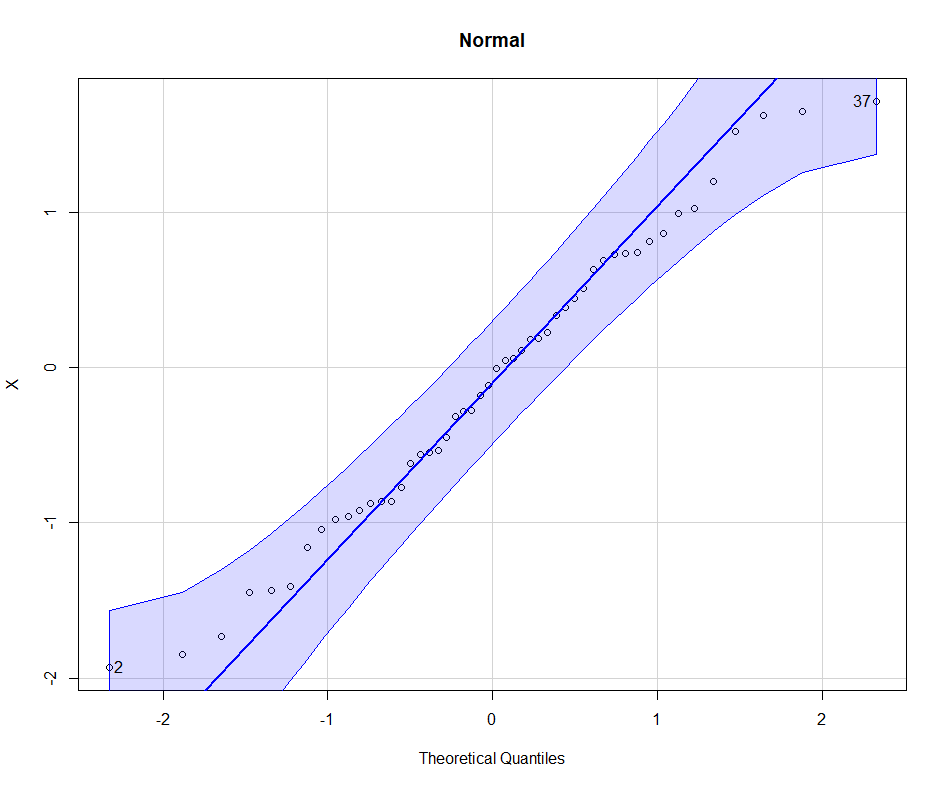

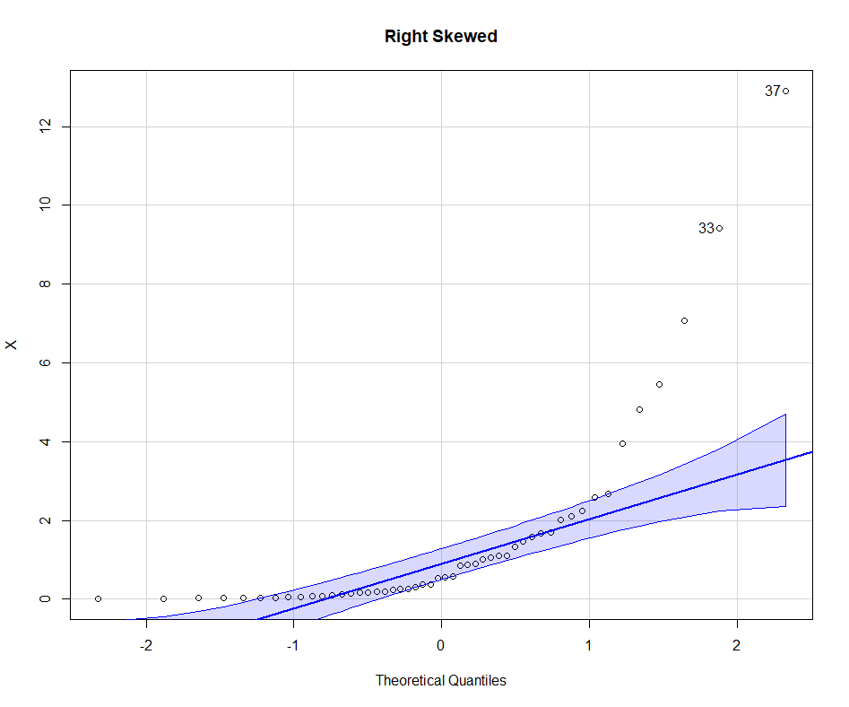

These work much better for small sample sizes. Below are several examples of QQPlots for small sample sizes:

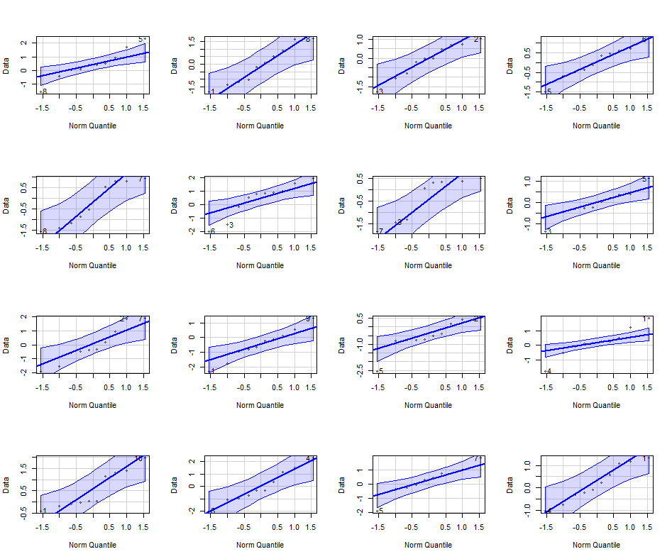

While not perfect, these are a vastly better tool to assess normality than a histogram.

# Practice

Let’s try assessing the normality of some data. Below are 3 datasets. Find the response variable(s) from each and determine if the data are sufficiently normally distributed:

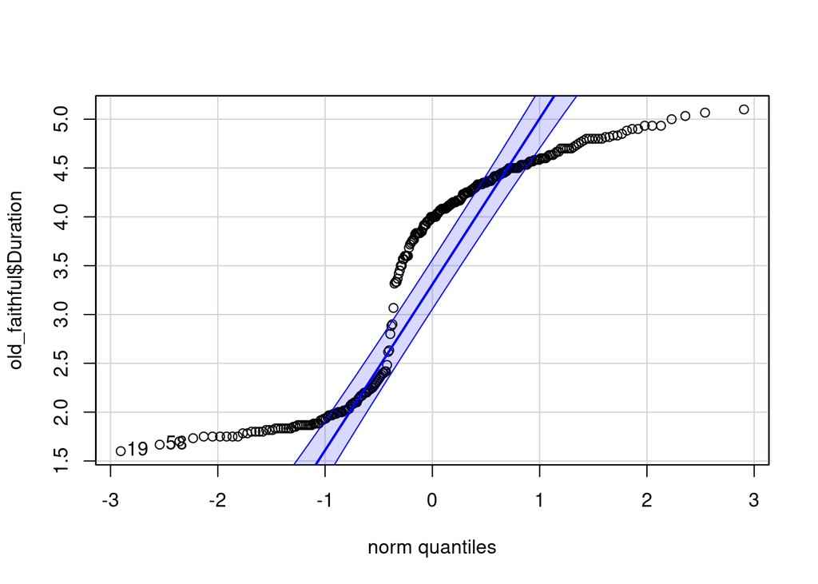

```
[1] 19 58
```

```r
library(rio)
library(tidyverse)
library(car)

old_faithful <- import('https://github.com/byuistats/Math221D_Cannon/raw/master/Data/OldFaithful.xlsx')

qqPlot(old_faithful$Duration)
```

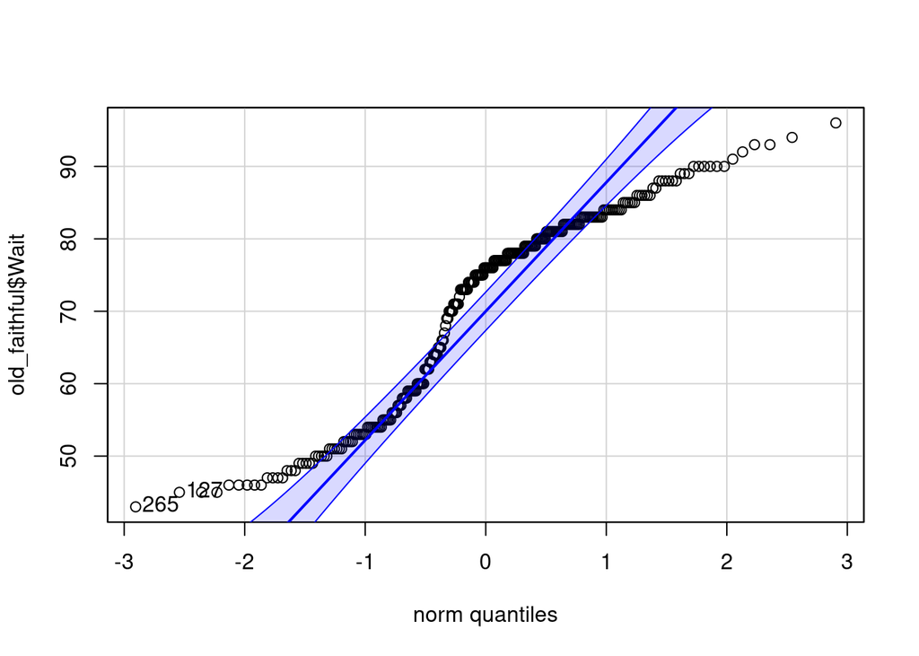

```
[1] 265 127
```

```r
qqPlot(old_faithful$Wait)
```

```r
rent <- import('https://github.com/byuistats/Math221D_Cannon/raw/master/Data/Rent.csv')


mcat_gpa <- import('https://github.com/byuistats/Math221D_Cannon/raw/master/Data/mcat_gpa.csv')
```